# Analysis of Factors Associated with Poor Response to Nutritional Treatment in Severely Malnourished Children Aged 6–59 Months With Edema and With Complications Treated (Phase T).

Doubata Dramane Marius COULIBALY

2026-09-20

## 1. Methodology

Descriptive analyses were conducted to characterize the cohort and the non-response to the nutritional treatment. Continuous variables were summarized using medians and interquartile ranges (25<sup>th</sup> - 75<sup>th</sup> percentile) due to their non-normal distribution, whereas categorical variables were summarized as counts and percentages (%).

Differences between groups (success and failure) were assessed using the Wilcoxon rank-sum test or Kruskal–Wallis test for continuous variables and Pearson’s chi-square or Fisher’s exact test for categorical variables, as appropriate.

Univariable logistic regression analyses were performed to estimate crude associations between independent variables and the dependent variable. Variables considered clinically relevant or statistically associated with the non-response to the nutritional treatment at *p* < 0.20 were included in a multivariable logistic regression.

Prior to model building, pairwise correlations among independent variables were examined to identify highly correlated predictors and assess potential multicollinearity. Pearson correlation coefficients were computed for continuous variables (or Spearman’s rank correlations for non-normally distributed variables). Variables exhibiting strong correlations (|r| $\geq 0.70$) were carefully evaluated to avoid redundancy. Variance Inflation Factors (VIFs) were subsequently calculated in the multivariable model, with VIF values > 5 indicating potential multicolliniarity.

Model selection was guided by likelihood ratio tests and the principle of parsimony. A stepwise selection procedure was used to identify the most parsimonious model (based on the Akaike Information Criterion (AIC)) by retaining variables that improved model fit while excluding predictors that contributed little additional information.

Adjusted odds ratios (aORs) with 95% confidence intervals (CIs) were reported. Statistical significance in the final model was defined as a two-sided *p* < 0.05. A variable was significantly associated with the risk of nutritional treatment failure if: i) the odds ratio (OR) was > 1 with a lower limit of the confidence interval (CI) > 1; or ii) OR<1 with upper CI limit <1; and p-value was <0.05.

All analyses were conducted using R (version 4.3.0).

## 3. **Descriptive Characteristics**

### 4. **Bivariate Analysis**

| Characteristic | Non-response to treatment in Phase FALSE N = 1251 | Non-response to treatment in Phase TRUE N = 501 | Non-response to treatment in Phase Overall N = 1751 | p-value23 | q-value4 |
| --- | --- | --- | --- | --- | --- |
| Age (Month) |  |  |  | 0.389 | 0.472 |
| Median (Q1 ; Q3) | 26 (19.0 ; 32) | 25 (18.0 ; 30) | 26 (18.0 ; 32) |  |  |
| Min ; Max | 7 ; 59.0 | 8 ; 48.0 | 7 ; 59.0 |  |  |
| Age group |  |  |  | 0.811 | 0.862 |
| [25;59] | 65 (52.0%) | 25 (50.0%) | 90 (51.4%) |  |  |
| [6;25[ | 60 (48.0%) | 25 (50.0%) | 85 (48.6%) |  |  |
| Gender |  |  |  | 0.039* | 0.148 |
| Male | 74 (59.2%) | 21 (42.0%) | 95 (54.3%) |  |  |
| Female | 51 (40.8%) | 29 (58.0%) | 80 (45.7%) |  |  |
| Locality |  |  |  | 0.094 | 0.216 |
| Urban | 23 (18.9%) | 15 (30.6%) | 38 (22.2%) |  |  |
| Rural | 99 (81.1%) | 34 (69.4%) | 133 (77.8%) |  |  |
| Missing values | 3 | 1 | 4 |  |  |
| Vaccination status |  |  |  | 0.191 | 0.324 |
| Up to date | 39 (81.3%) | 11 (64.7%) | 50 (76.9%) |  |  |
| Out of date | 9 (18.8%) | 6 (35.3%) | 15 (23.1%) |  |  |
| Missing values | 77 | 33 | 110 |  |  |
| Breastfeeding status | 64 (88.9%) | 27 (79.4%) | 91 (85.8%) | 0.235 | 0.381 |
| Missing values | 53 | 16 | 69 |  |  |
| Type admission |  |  |  | 0.984 | 0.984 |
| New admission | 108 (89.3%) | 42 (89.4%) | 150 (89.3%) |  |  |
| Readmission | 13 (10.7%) | 5 (10.6%) | 18 (10.7%) |  |  |
| Missing values | 4 | 3 | 7 |  |  |
| Morbidity burden |  |  |  | <0.001*** | 0.001 |
| Median (Q1 ; Q3) | 1 (1.0 ; 2) | 2 (1.0 ; 3) | 2 (1.0 ; 3) |  |  |
| Min ; Max | 0 ; 4.0 | 0 ; 5.0 | 0 ; 5.0 |  |  |
| Shock | 0 (0.0%) | 1 (2.0%) | 1 (0.6%) | 0.286 | 0.389 |
| Gastroenteritis | 56 (44.8%) | 38 (76.0%) | 94 (53.7%) | <0.001*** | 0.002 |
| Pneumonia | 53 (42.4%) | 27 (54.0%) | 80 (45.7%) | 0.164 | 0.294 |
| Tuberculosis | 0 (0.0%) | 1 (2.0%) | 1 (0.6%) | 0.286 | 0.389 |

[output cut: 60 more lines]

1n (%)  
2Wilcoxon rank sum test; Pearson's Chi-squared test; Fisher's exact test; NA  
3*p<0.05; **p<0.01; ***p<0.001  
4False discovery rate correction for multiple testing

### Sociodemographic

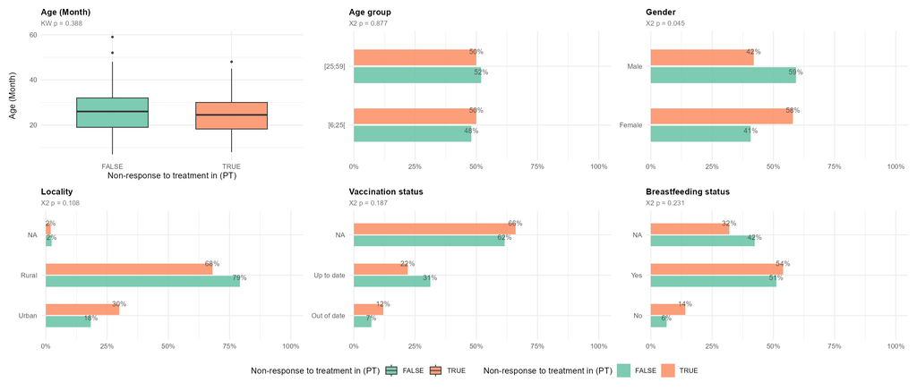

### Clinical Admission and Severity

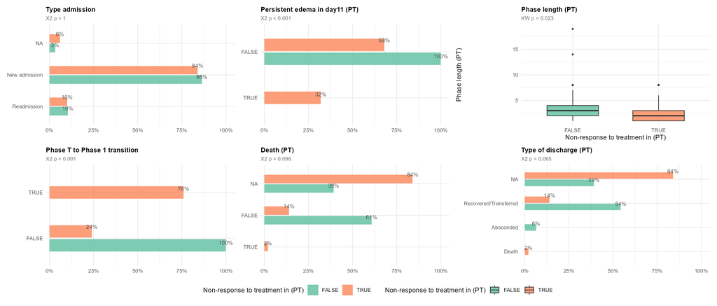

### Nutritional Treatment

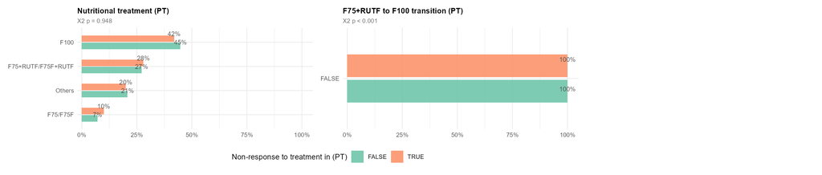

### Feeding Compliance

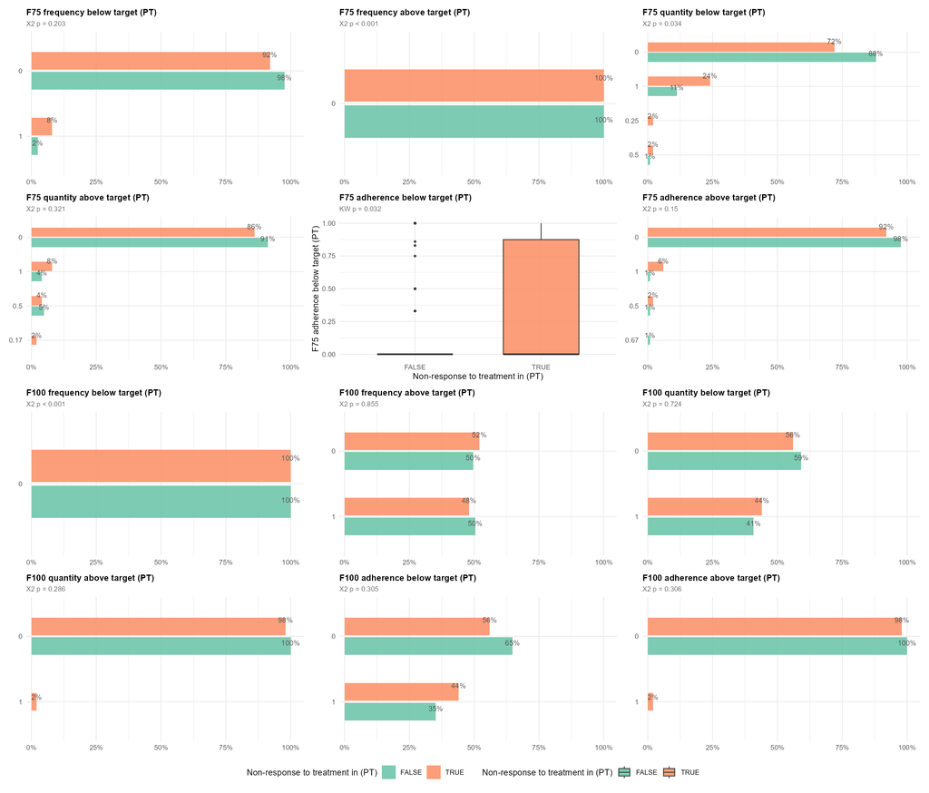

### Morbidity and Comorbidities

#### General

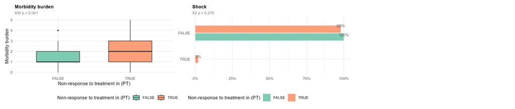

#### Infections and Parasitic

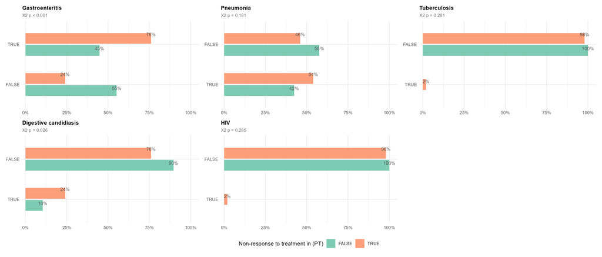

#### Malaria

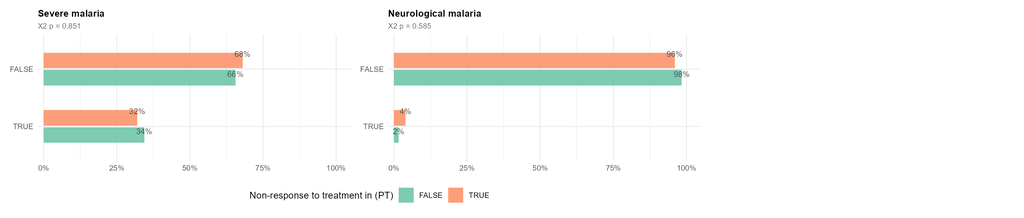

#### Anaemia

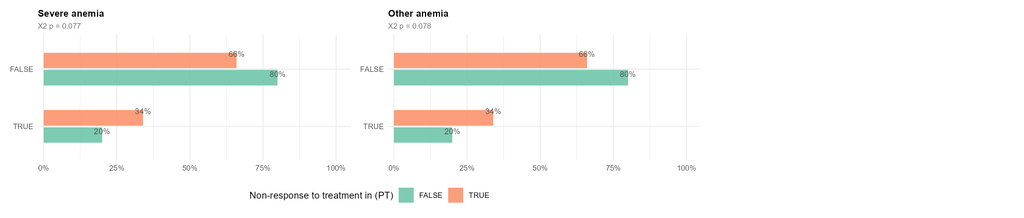

**Table 2:** Results of the univariate logistic regression analysis between explanatory variables and outcome.

| Predictor | Event N | OR | 95% CI | p-value |
| --- | --- | --- | --- | --- |
| Gastroenteritis |  |  |  | <0.001 |
| FALSE | 12 | — | — |  |
| TRUE | 38 | 3.90 | 1.91, 8.45 |  |
| Digestive candidiasis |  |  |  | 0.026 |
| FALSE | 38 | — | — |  |
| TRUE | 12 | 2.72 | 1.13, 6.51 |  |
| Gender |  |  |  | 0.039 |
| Male | 21 | — | — |  |
| Female | 29 | 2.00 | 1.04, 3.94 |  |
| Severe anemia |  |  |  | 0.055 |
| FALSE | 33 | — | — |  |
| TRUE | 17 | 2.06 | 0.98, 4.27 |  |
| F75 adherence below target (PT) |  |  |  | 0.057 |
| 0 | 34 | — | — |  |
| ]0;100] | 16 | 2.09 | 0.98, 4.40 |  |
| F75 adherence above target (PT) |  |  |  | 0.11 |
| 0 | 46 | — | — |  |
| ]0;100] | 4 | 3.54 | 0.75, 18.5 |  |
| Pneumonia |  |  |  | 0.2 |
| FALSE | 23 | — | — |  |
| TRUE | 27 | 1.59 | 0.83, 3.10 |  |
| Severe malaria |  |  |  | 0.8 |
| FALSE | 34 | — | — |  |
| TRUE | 16 | 0.90 | 0.44, 1.79 |  |
| Age group |  |  |  | 0.8 |
| [25;59] | 25 | — | — |  |
| [6;25[ | 25 | 1.08 | 0.56, 2.09 |  |

Abbreviations: CI = Confidence Interval, OR = Odds Ratio

# 5. Multivariate logistic regression analyses

Table 3 : Results of the generalize logistic regression analysis at Phase T.

| Predictor | N | Event N | OR1 | 95% CI | p-value | q-value2 | VIF |
| --- | --- | --- | --- | --- | --- | --- | --- |
| Gastroenteritis | 175 |  | *** |  | <0.001 | 0.001 | 1.0 |
| FALSE |  | 12 |  | — |  |  |  |
| TRUE |  | 38 | 3.64 | 1.75, 7.98 |  |  |  |
| Gender | 175 |  |  |  | 0.050 | 0.074 | 1.0 |
| Male |  | 21 |  | — |  |  |  |
| Female |  | 29 | 2.00 | 1.00, 4.07 |  |  |  |
| Severe anemia | 175 |  |  |  | 0.2 | 0.2 | 1.0 |
| FALSE |  | 33 |  | — |  |  |  |
| TRUE |  | 17 | 1.77 | 0.80, 3.84 |  |  |  |

1*p<0.05; **p<0.01; ***p<0.001  
2False discovery rate correction for multiple testing  
Abbreviations: CI = Confidence Interval, OR = Odds Ratio, VIF = Variance Inflation Factor